# Exercise7: Advanced Raster Analysis for the geoScripting course

AD-Scripting: Astrid Bos & David Scholte-Albers

Friday, January 16, 2015

This script creates a linear model using the Landsat band reflectance values as predictors for tree cover. The resulting model is compared with the values of the VCF product and its accuracy is analysed using the RMSE of the model.

## Preprocessing of the data

```r
# Load band data and training polygons
load("data/GewataB1.rda")
load("data/GewataB2.rda")
load("data/GewataB3.rda")
load("data/GewataB4.rda")
load("data/GewataB5.rda")
load("data/GewataB7.rda")
load("data/vcfGewata.rda") #Vegetation Continuous Field
load("data/trainingPoly.rda")

# Remove outliers (Based on histogram and summary of each band)
GewataB1[GewataB1 > 1000] <- NA
GewataB2[GewataB2 > 1300] <- NA
GewataB3[GewataB3 > 1500] <- NA
GewataB5[GewataB5 > 4000] <- NA
GewataB7[GewataB7 > 3000] <- NA

# Remove water, clouds and shadows from VCF
vcfGewata[vcfGewata > 100] <- NA

# Combine bands in a rasterBrick and convert to original values
gewata <- brick(GewataB1, GewataB2, GewataB3, GewataB4, GewataB5, GewataB7)
gewata <- calc(gewata, fun=function(x) x / 10000)
```

## Analysis of relationship between Landsat bands and VCF

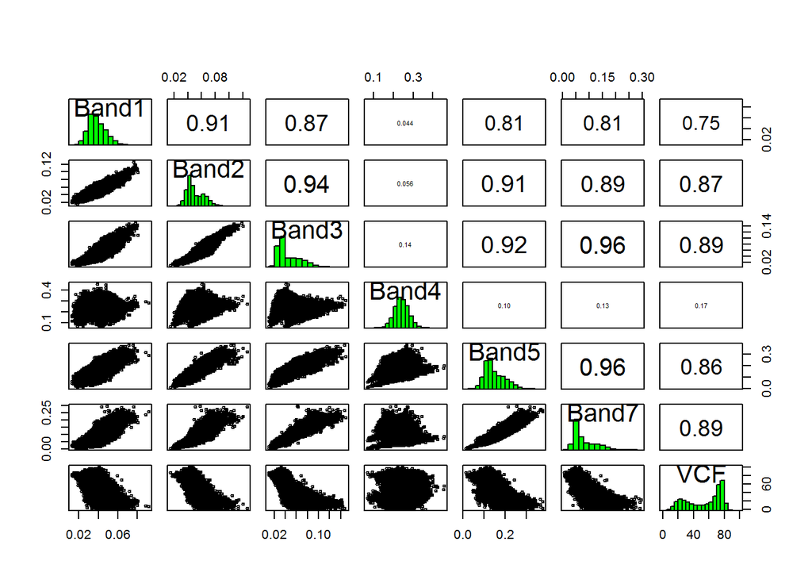

```r
# Relationship between bands and VCF
covs <- addLayer(gewata, vcfGewata)
names(covs) <- c("Band1", "Band2", "Band3", "Band4", "Band5", "Band7", "VCF")
pairs(covs)
```

Band 3 and 7 have the highest correlation coefficient with the VCF (both 0.89). Surprisingly band 4 (NIR)has the lowest correlation coefficient with the VCF (0.17).

## Linear model

```r
# Linear model
covsdf <- as.data.frame(covs, na.rm=T)
model <- lm(VCF ~ Band1 + Band2 + Band3 + Band4 + Band5 + Band7, data = covsdf)
```

```r
summary(model)
```

```
##
## Call:
## lm(formula = VCF ~ Band1 + Band2 + Band3 + Band4 + Band5 + Band7,
##     data = covsdf)
##
## Residuals:
##     Min      1Q  Median      3Q     Max
## -58.029  -4.634   0.711   5.207  56.503
##
## Coefficients:
##               Estimate Std. Error t value Pr(>|t|)
## (Intercept)  8.589e+01  5.738e-02 1496.92   <2e-16 ***
## Band1        9.265e+02  1.888e+00  490.74   <2e-16 ***
## Band2       -1.513e+03  2.354e+00 -642.87   <2e-16 ***
## Band3       -1.835e+01  1.746e+00  -10.51   <2e-16 ***
## Band4        1.637e+02  2.842e-01  576.04   <2e-16 ***
## Band5       -1.917e+02  7.432e-01 -257.89   <2e-16 ***
## Band7       -1.135e+01  9.831e-01  -11.55   <2e-16 ***
## ---
## Signif. codes:  0 '***' 0.001 '**' 0.01 '*' 0.05 '.' 0.1 ' ' 1
##
## Residual standard error: 8.582 on 1808039 degrees of freedom
## Multiple R-squared:  0.859,  Adjusted R-squared:  0.859
## F-statistic: 1.836e+06 on 6 and 1808039 DF,  p-value: < 2.2e-16
```

In the Pr(>|t|), which represents the variable p-value, all bands show a very low value, which means that the chance that the band is meaningless for the model is very low. All bands have 3 stars, corresponding with a very good significance. For more information on this subject: http://blog.yhathq.com/posts/r-lm-summary.html

```r
# Prediction of tree cover based on the model
vcf_predict <- predict(covs, model, na.rm=T)
vcf_predict[vcf_predict < 0] <- NA
vcf_dif <- vcf_predict - vcfGewata
```

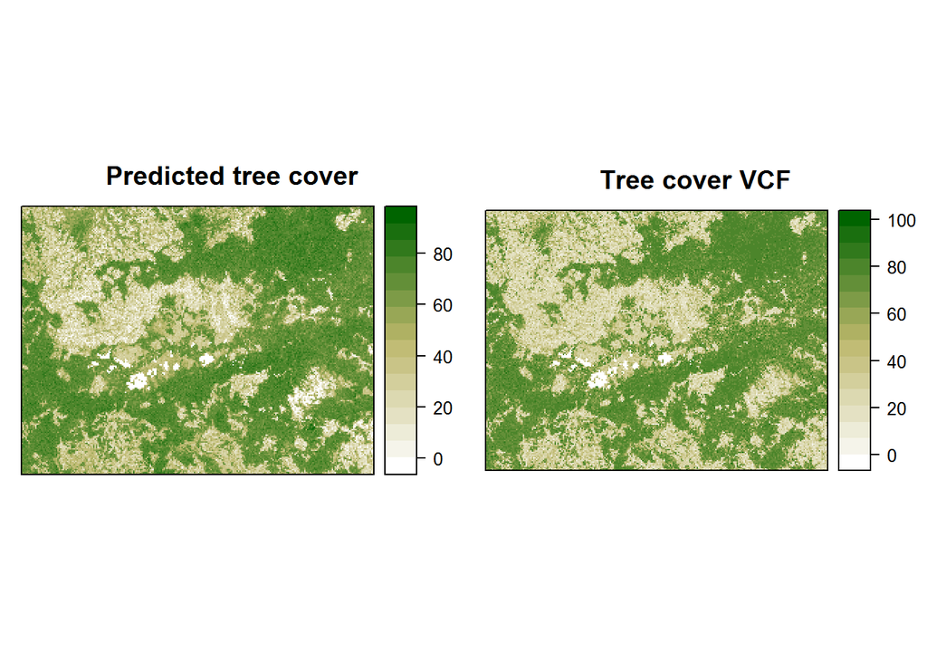

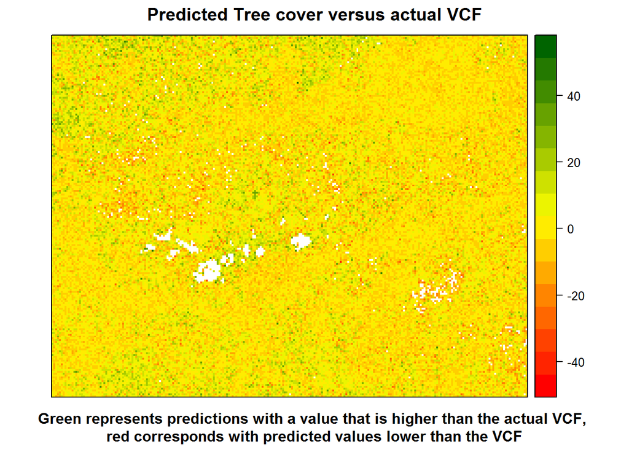

## Accuracy assessment of the model using RMSE

```r
# Root mean squared Error for difference in predicted and actual tree cover
dif_df <- as.data.frame(vcf_predict$Treecover - covs$VCF, na.rm=T)
RMSE <- round(sqrt(mean(dif_df ^ 2)), digits=2)
RMSE
```

```
## [1] 8.35
```

The RMSE for the difference in predicted and actural tree cover is 8.35

## RMSE for different land use classes using training data

```r
# Set up trainings data
trainingPoly@data$Code <- as.numeric(trainingPoly@data$Class)

# Assign "code" values to raster cells
land_use_classes <- rasterize(trainingPoly, covs$VCF, field='Code')

# Brick with predicted and actual tree cover
pred_act_brick <- brick(covs$VCF, vcf_predict)

# Calculate the mean for every class by the use of zonal()
mean_cover <- zonal(pred_act_brick, land_use_classes, fun='mean',na.rm=T)
mean_cover_df <- as.data.frame(mean_cover)

# Calculate the Root mean squared Error for all of the 3 classes
rmse_mean_cover <- round(sqrt((mean_cover_df$VCF - mean_cover_df$layer)^2), digits=2)
names(rmse_mean_cover) <- c("Crop", "Forest", "Wetlands")
rmse_mean_cover
```

```
##     Crop   Forest Wetlands
##     2.55     2.30     6.86
```

The rmse is different for the different landuse classes. Crop has a rmse of 2.55, forest has a rmse of 2.30 and wetlands has a rmse for the prediction of 6.86